# SI_02_GRANT_US_ORG_ADDR_L2

Grantee street address line 2 · Text report

## Overview

**Description**

Address Foreign - AddressLine2

**Table**

`SI-P02-T01-GRANTS-US-ORGS-GOVTS` (many)

**Location code**

`SCHED-I-PART-02-LINE-01-COL-A`

**Family**

`SCHED-I-PART-02-LINE-01-COL-A` · siblings: SI_02_GRANT_US_ORG_ADDR_CITY, SI_02_GRANT_US_ORG_ADDR_CNTR, SI_02_GRANT_US_ORG_ADDR_L1, SI_02_GRANT_US_ORG_ADDR_STATE, SI_02_GRANT_US_ORG_ADDR_ZIP, SI_02_GRANT_US_ORG_NAME_L1

**Data type**

text (xsd: , StreetAddressType)

**Scope**

PC

**Status**

unreviewed

8

xpaths mapped (6 observed)

41,138

filings with a value

2009–2024

tax years observed

3

open flags (1 errors)

## Flags

| Severity | Flag | Xpath | Detail |
| --- | --- | --- | --- |
| ⚠ error | `COLLISION` | IRS990ScheduleI/RecipientTable/ForeignAddress/AddressLine2Txt | 108 filings contain 2+ of its xpaths; most common set: /Return/ReturnData/IRS990ScheduleI/RecipientTable/ForeignAddress/AddressLine2Txt ; /Return/ReturnData/IRS990ScheduleI/RecipientTable/USAddress/Ad… |
| ⓘ info | `UNOBSERVED` | IRS990ScheduleI/Form990ScheduleIPartII/RecipientTable/AddressForeign/AddressLine2 | never observed in TY2009-2024 filings |
| ⓘ info | `UNOBSERVED` | IRS990ScheduleI/Form990ScheduleIPartII/RecipientTable/AddressUS/AddressLine2 | never observed in TY2009-2024 filings |

## Xpaths

All mapped xpaths (under /Return/ReturnData or /Return/ReturnHeader), oldest first. Charts label each series by its xpath.

| Xpath | Form | Chart label | First year | Last year | Versions | Filings | Repeats in |
| --- | --- | --- | --- | --- | --- | --- | --- |
| IRS990ScheduleI/RecipientTable/AddressUS/AddressLine2 | Sched I | same | 2009 | 2012 | 16 | 5,467 | 46.1% |
| IRS990ScheduleI/RecipientTable/AddressForeign/AddressLine2 | Sched I | same | 2009 | 2012 | 5 | 10 | 30.0% |
| IRS990ScheduleI/RecipientTable/USAddress/AddressLine2 | Sched I | same | 2013 | 2013 | 3 | 2,048 | 42.8% |
| IRS990ScheduleI/RecipientTable/ForeignAddress/AddressLine2 | Sched I | same | 2013 | 2013 | 2 | 6 | 0.0% |
| IRS990ScheduleI/RecipientTable/USAddress/AddressLine2Txt | Sched I | same | 2014 | 2024 | 33 | 33,459 | 42.7% |
| IRS990ScheduleI/RecipientTable/ForeignAddress/AddressLine2Txt | Sched I | …90ScheduleI/RecipientTable/ForeignAddress/AddressLine2Txt | 2014 | 2024 | 25 | 148 | 15.5% |
| IRS990ScheduleI/Form990ScheduleIPartII/RecipientTable/AddressForeign/AddressLine2 | Sched I | …cheduleIPartII/RecipientTable/AddressForeign/AddressLine2 |  |  |  | 0 |  |
| IRS990ScheduleI/Form990ScheduleIPartII/RecipientTable/AddressUS/AddressLine2 | Sched I | …m990ScheduleIPartII/RecipientTable/AddressUS/AddressLine2 |  |  |  | 0 |  |

## Coverage

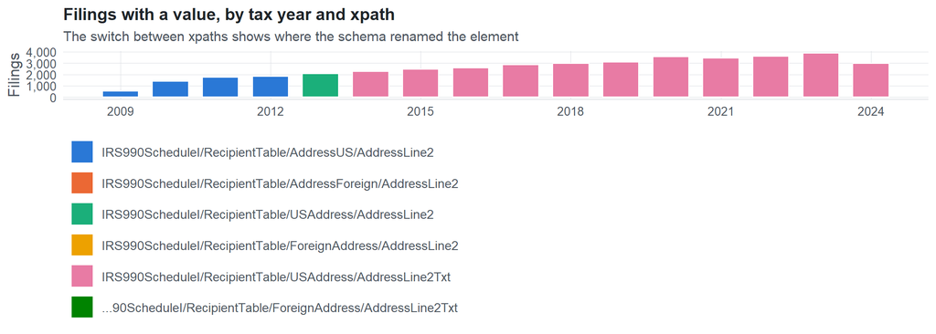

**Table view**

Table view: filings by tax year and series

| Tax year | IRS990ScheduleI/RecipientTable/AddressUS/AddressLine2 | IRS990ScheduleI/RecipientTable/AddressForeign/AddressLine2 | IRS990ScheduleI/RecipientTable/USAddress/AddressLine2 | IRS990ScheduleI/RecipientTable/ForeignAddress/AddressLine2 | IRS990ScheduleI/RecipientTable/USAddress/AddressLine2Txt | …90ScheduleI/RecipientTable/ForeignAddress/AddressLine2Txt |
| --- | --- | --- | --- | --- | --- | --- |
| 2009 | 517 | 1 | 0 | 0 | 0 | 0 |
| 2010 | 1,379 | 1 | 0 | 0 | 0 | 0 |
| 2011 | 1,753 | 5 | 0 | 0 | 0 | 0 |
| 2012 | 1,818 | 3 | 0 | 0 | 0 | 0 |
| 2013 | 0 | 0 | 2,048 | 6 | 0 | 0 |
| 2014 | 0 | 0 | 0 | 0 | 2,259 | 6 |
| 2015 | 0 | 0 | 0 | 0 | 2,435 | 8 |
| 2016 | 0 | 0 | 0 | 0 | 2,555 | 12 |
| 2017 | 0 | 0 | 0 | 0 | 2,825 | 20 |
| 2018 | 0 | 0 | 0 | 0 | 2,970 | 5 |
| 2019 | 0 | 0 | 0 | 0 | 3,058 | 10 |
| 2020 | 0 | 0 | 0 | 0 | 3,525 | 22 |
| 2021 | 0 | 0 | 0 | 0 | 3,434 | 21 |
| 2022 | 0 | 0 | 0 | 0 | 3,573 | 15 |
| 2023 | 0 | 0 | 0 | 0 | 3,868 | 18 |
| 2024 | 0 | 0 | 0 | 0 | 2,957 | 11 |

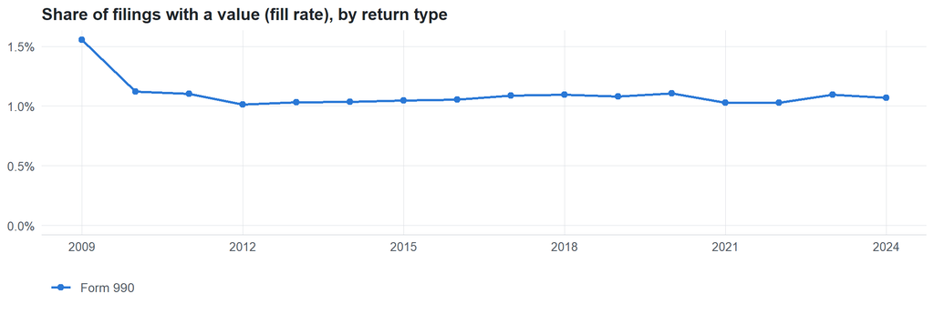

**Table view**

Table view: fill rate

| Tax year | Return type | Filings | All filings | Fill rate |
| --- | --- | --- | --- | --- |
| 2009 | Form 990 | 518 | 33,311 | 1.56% |
| 2010 | Form 990 | 1,380 | 123,025 | 1.12% |
| 2011 | Form 990 | 1,758 | 159,504 | 1.10% |
| 2012 | Form 990 | 1,821 | 179,688 | 1.01% |
| 2013 | Form 990 | 2,054 | 198,855 | 1.03% |
| 2014 | Form 990 | 2,265 | 218,619 | 1.04% |
| 2015 | Form 990 | 2,443 | 233,519 | 1.05% |
| 2016 | Form 990 | 2,567 | 243,903 | 1.05% |
| 2017 | Form 990 | 2,845 | 261,612 | 1.09% |
| 2018 | Form 990 | 2,975 | 271,442 | 1.10% |
| 2019 | Form 990 | 3,068 | 283,694 | 1.08% |
| 2020 | Form 990 | 3,547 | 320,342 | 1.11% |
| 2021 | Form 990 | 3,455 | 336,480 | 1.03% |
| 2022 | Form 990 | 3,588 | 349,055 | 1.03% |
| 2023 | Form 990 | 3,886 | 354,768 | 1.10% |
| 2024 | Form 990 | 2,968 | 277,298 | 1.07% |

## Repeating groups

Table cardinality in the concordance: **many**. 5 of 6 observed xpaths repeat within a filing.

Repeating element each xpath was observed in (from the raw indexed xpath)

| Xpath | Repeating element | Filings (summed over years) |
| --- | --- | --- |
| IRS990ScheduleI/RecipientTable/AddressForeign/AddressLine2 | IRS990ScheduleI/RecipientTable | 9 |
| IRS990ScheduleI/RecipientTable/AddressUS/AddressLine2 | (none) | 736 |
| IRS990ScheduleI/RecipientTable/AddressUS/AddressLine2 | IRS990ScheduleI/RecipientTable | 4731 |
| IRS990ScheduleI/RecipientTable/AddressForeign/AddressLine2 | (none) | 1 |
| IRS990ScheduleI/RecipientTable/ForeignAddress/AddressLine2 | (none) | 1 |
| IRS990ScheduleI/RecipientTable/ForeignAddress/AddressLine2 | IRS990ScheduleI/RecipientTable | 5 |
| IRS990ScheduleI/RecipientTable/USAddress/AddressLine2 | (none) | 332 |
| IRS990ScheduleI/RecipientTable/USAddress/AddressLine2 | IRS990ScheduleI/RecipientTable | 1716 |
| IRS990ScheduleI/RecipientTable/ForeignAddress/AddressLine2Txt | (none) | 5 |
| IRS990ScheduleI/RecipientTable/ForeignAddress/AddressLine2Txt | IRS990ScheduleI/RecipientTable | 143 |
| IRS990ScheduleI/RecipientTable/USAddress/AddressLine2Txt | (none) | 4815 |
| IRS990ScheduleI/RecipientTable/USAddress/AddressLine2Txt | IRS990ScheduleI/RecipientTable | 28644 |

## Values

[output not shown]

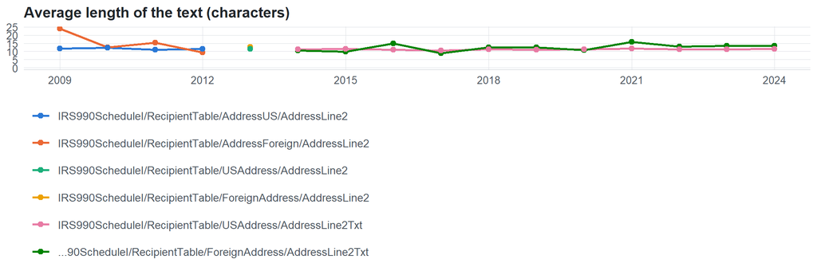

**Table view**

Table view: length and variety by tax year

| Series | Tax year | Filings | Avg length | Max length | Distinct values (approx.) |
| --- | --- | --- | --- | --- | --- |
| IRS990ScheduleI/RecipientTable/AddressUS/AddressLine2 | 2009 | 517 | 12 | 35 | 1,863 |
| IRS990ScheduleI/RecipientTable/AddressUS/AddressLine2 | 2010 | 1,379 | 12 | 35 | 3,062 |
| IRS990ScheduleI/RecipientTable/AddressUS/AddressLine2 | 2011 | 1,753 | 11 | 35 | 3,867 |
| IRS990ScheduleI/RecipientTable/AddressUS/AddressLine2 | 2012 | 1,818 | 11 | 35 | 3,246 |
| IRS990ScheduleI/RecipientTable/AddressForeign/AddressLine2 | 2009 | 1 | 24 | 24 | 1 |
| IRS990ScheduleI/RecipientTable/AddressForeign/AddressLine2 | 2010 | 1 | 12 | 25 | 9 |
| IRS990ScheduleI/RecipientTable/AddressForeign/AddressLine2 | 2011 | 5 | 15 | 35 | 7 |
| IRS990ScheduleI/RecipientTable/AddressForeign/AddressLine2 | 2012 | 3 | 9 | 11 | 2 |
| IRS990ScheduleI/RecipientTable/USAddress/AddressLine2 | 2013 | 2,048 | 11 | 35 | 2,533 |
| IRS990ScheduleI/RecipientTable/ForeignAddress/AddressLine2 | 2013 | 6 | 13 | 27 | 5 |
| IRS990ScheduleI/RecipientTable/USAddress/AddressLine2Txt | 2014 | 2,259 | 11 | 35 | 4,709 |
| IRS990ScheduleI/RecipientTable/USAddress/AddressLine2Txt | 2015 | 2,435 | 11 | 35 | 4,069 |
| IRS990ScheduleI/RecipientTable/USAddress/AddressLine2Txt | 2016 | 2,555 | 11 | 35 | 7,583 |
| IRS990ScheduleI/RecipientTable/USAddress/AddressLine2Txt | 2017 | 2,825 | 11 | 35 | 7,076 |
| IRS990ScheduleI/RecipientTable/USAddress/AddressLine2Txt | 2018 | 2,970 | 11 | 35 | 6,417 |
| IRS990ScheduleI/RecipientTable/USAddress/AddressLine2Txt | 2019 | 3,058 | 11 | 35 | 4,008 |
| IRS990ScheduleI/RecipientTable/USAddress/AddressLine2Txt | 2020 | 3,525 | 11 | 35 | 4,750 |
| IRS990ScheduleI/RecipientTable/USAddress/AddressLine2Txt | 2021 | 3,434 | 12 | 35 | 9,496 |
| IRS990ScheduleI/RecipientTable/USAddress/AddressLine2Txt | 2022 | 3,573 | 11 | 35 | 13,567 |
| IRS990ScheduleI/RecipientTable/USAddress/AddressLine2Txt | 2023 | 3,868 | 11 | 35 | 8,141 |
| IRS990ScheduleI/RecipientTable/USAddress/AddressLine2Txt | 2024 | 2,957 | 11 | 35 | 5,414 |
| …90ScheduleI/RecipientTable/ForeignAddress/AddressLine2Txt | 2014 | 6 | 11 | 20 | 5 |
| …90ScheduleI/RecipientTable/ForeignAddress/AddressLine2Txt | 2015 | 8 | 10 | 27 | 5 |
| …90ScheduleI/RecipientTable/ForeignAddress/AddressLine2Txt | 2016 | 12 | 15 | 33 | 11 |
| …90ScheduleI/RecipientTable/ForeignAddress/AddressLine2Txt | 2017 | 20 | 9 | 22 | 12 |
| …90ScheduleI/RecipientTable/ForeignAddress/AddressLine2Txt | 2018 | 5 | 12 | 35 | 5 |
| …90ScheduleI/RecipientTable/ForeignAddress/AddressLine2Txt | 2019 | 10 | 12 | 29 | 5 |
| …90ScheduleI/RecipientTable/ForeignAddress/AddressLine2Txt | 2020 | 22 | 11 | 27 | 16 |
| …90ScheduleI/RecipientTable/ForeignAddress/AddressLine2Txt | 2021 | 21 | 16 | 35 | 30 |
| …90ScheduleI/RecipientTable/ForeignAddress/AddressLine2Txt | 2022 | 15 | 13 | 35 | 25 |
| …90ScheduleI/RecipientTable/ForeignAddress/AddressLine2Txt | 2023 | 18 | 13 | 35 | 18 |
| …90ScheduleI/RecipientTable/ForeignAddress/AddressLine2Txt | 2024 | 11 | 13 | 31 | 9 |

Most common values by xpath (all years; long values truncated)

| Series | Value | Filings | Share |
| --- | --- | --- | --- |
| IRS990ScheduleI/RecipientTable/AddressUS/AddressLine2 | FLOOR | 226 | 4.1% |
| IRS990ScheduleI/RecipientTable/AddressUS/AddressLine2 | STREET | 182 | 3.3% |
| IRS990ScheduleI/RecipientTable/AddressUS/AddressLine2 | 200 | 147 | 2.7% |
| IRS990ScheduleI/RecipientTable/AddressUS/AddressLine2 | 100 | 135 | 2.5% |
| IRS990ScheduleI/RecipientTable/AddressUS/AddressLine2 | SUITE 200 | 118 | 2.2% |
| IRS990ScheduleI/RecipientTable/AddressUS/AddressLine2 | AVENUE | 116 | 2.1% |
| IRS990ScheduleI/RecipientTable/AddressUS/AddressLine2 | Suite 200 | 112 | 2.0% |
| IRS990ScheduleI/RecipientTable/AddressUS/AddressLine2 | 300 | 84 | 1.5% |
| IRS990ScheduleI/RecipientTable/AddressUS/AddressLine2 | SUITE 100 | 64 | 1.2% |
| IRS990ScheduleI/RecipientTable/AddressUS/AddressLine2 | DRIVE | 58 | 1.1% |
| IRS990ScheduleI/RecipientTable/AddressUS/AddressLine2 | Suite 300 | 44 | 0.8% |
| IRS990ScheduleI/RecipientTable/AddressUS/AddressLine2 | ST | 28 | 0.5% |
| IRS990ScheduleI/RecipientTable/AddressUS/AddressLine2 | SUITE 300 | 20 | 0.4% |
| IRS990ScheduleI/RecipientTable/AddressUS/AddressLine2 | Street | 19 | 0.3% |
| IRS990ScheduleI/RecipientTable/AddressUS/AddressLine2 | Floor | 16 | 0.3% |
| IRS990ScheduleI/RecipientTable/AddressUS/AddressLine2 | Avenue | 12 | 0.2% |
| IRS990ScheduleI/RecipientTable/AddressUS/AddressLine2 | Suite 100 | 12 | 0.2% |
| IRS990ScheduleI/RecipientTable/AddressForeign/AddressLine2 | 264 Matadero St Suite 11 | 1 | 10.0% |
| IRS990ScheduleI/RecipientTable/AddressForeign/AddressLine2 | 1300-329 | 1 | 10.0% |
| IRS990ScheduleI/RecipientTable/AddressForeign/AddressLine2 | Cuore Ferrari | 1 | 10.0% |
| IRS990ScheduleI/RecipientTable/AddressForeign/AddressLine2 | Diliman | 1 | 10.0% |
| IRS990ScheduleI/RecipientTable/AddressForeign/AddressLine2 | Karachi | 1 | 10.0% |
| IRS990ScheduleI/RecipientTable/AddressForeign/AddressLine2 | No 5 | 1 | 10.0% |
| IRS990ScheduleI/RecipientTable/AddressForeign/AddressLine2 | Savvinkiy Pereulok | 1 | 10.0% |
| IRS990ScheduleI/RecipientTable/AddressForeign/AddressLine2 | Schiffbauerdamm 40 | 1 | 10.0% |
| IRS990ScheduleI/RecipientTable/AddressForeign/AddressLine2 | Street BGY Addition Hills | 1 | 10.0% |
| IRS990ScheduleI/RecipientTable/AddressForeign/AddressLine2 | Argentina | 1 | 10.0% |
| IRS990ScheduleI/RecipientTable/AddressForeign/AddressLine2 | Bicester | 1 | 10.0% |
| IRS990ScheduleI/RecipientTable/AddressForeign/AddressLine2 | INTERNATIONAL TRADE CENTER SUITE 12 | 1 | 10.0% |
| IRS990ScheduleI/RecipientTable/AddressForeign/AddressLine2 | Lira 125 | 1 | 10.0% |

First rows shown.

## Examples

| Tax year | Return | Xpath | Organization | Value | Source |
| --- | --- | --- | --- | --- | --- |
| 2024 | 990 | IRS990ScheduleI/RecipientTable/ForeignAddress/AddressLine2Txt | EDUCATIONAL CREDIT | 523 | [XML](https://gt990datalake-rawdata.s3.amazonaws.com/EfileData/XmlFiles/202503199349301740_public.xml) |
| 2024 | 990 | IRS990ScheduleI/RecipientTable/USAddress/AddressLine2Txt | JAMESTOWN FOUNDATION INC | VONFURSTENBERG BLDG | [XML](https://gt990datalake-rawdata.s3.amazonaws.com/EfileData/XmlFiles/202511649349300506_public.xml) |
| 2023 | 990 | IRS990ScheduleI/RecipientTable/ForeignAddress/AddressLine2Txt | The Rhodes Trust | South Parks Road | [XML](https://gt990datalake-rawdata.s3.amazonaws.com/EfileData/XmlFiles/202521339349303247_public.xml) |
| 2023 | 990 | IRS990ScheduleI/RecipientTable/USAddress/AddressLine2Txt | ASCENSION PROVIDENCE ROCHESTER FOUNDATION | PO BOX 45998 | [XML](https://gt990datalake-rawdata.s3.amazonaws.com/EfileData/XmlFiles/202511359349304421_public.xml) |
| 2022 | 990 | IRS990ScheduleI/RecipientTable/ForeignAddress/AddressLine2Txt | ZOOLOGICAL ASSOCIATION OF AMERICA | EDIFICIO PANORAMA 1-A | [XML](https://gt990datalake-rawdata.s3.amazonaws.com/EfileData/XmlFiles/202411419349301031_public.xml) |
| 2022 | 990 | IRS990ScheduleI/RecipientTable/USAddress/AddressLine2Txt | STATE POLICY NETWORK | 800 | [XML](https://gt990datalake-rawdata.s3.amazonaws.com/EfileData/XmlFiles/202321929349300837_public.xml) |
| 2021 | 990 | IRS990ScheduleI/RecipientTable/ForeignAddress/AddressLine2Txt | FAMILY OFFICE FOUNDATION INC | CHEUNG SHA WAN ROAD | [XML](https://gt990datalake-rawdata.s3.amazonaws.com/EfileData/XmlFiles/202243199349329319_public.xml) |
| 2021 | 990 | IRS990ScheduleI/RecipientTable/USAddress/AddressLine2Txt | MINNESOTA COLORECTAL CANCER RESEARCH | SE STE 500 | [XML](https://gt990datalake-rawdata.s3.amazonaws.com/EfileData/XmlFiles/202231369349311788_public.xml) |
| 2020 | 990 | IRS990ScheduleI/RecipientTable/ForeignAddress/AddressLine2Txt | THE COMMUNITY FOUNDATION OF MIDDLE | CENTRE | [XML](https://gt990datalake-rawdata.s3.amazonaws.com/EfileData/XmlFiles/202123169349307827_public.xml) |
| 2020 | 990 | IRS990ScheduleI/RecipientTable/USAddress/AddressLine2Txt | WACCAMAW COMMUNITY FOUNDATION | SUITE 128 | [XML](https://gt990datalake-rawdata.s3.amazonaws.com/EfileData/XmlFiles/202112429349300101_public.xml) |
| 2019 | 990 | IRS990ScheduleI/RecipientTable/ForeignAddress/AddressLine2Txt | President and Fellows of Harvard College | PMB 79 | [XML](https://gt990datalake-rawdata.s3.amazonaws.com/EfileData/XmlFiles/202131339349302713_public.xml) |
| 2019 | 990 | IRS990ScheduleI/RecipientTable/USAddress/AddressLine2Txt | Northwestern University | 1637 Old Louisburg Road | [XML](https://gt990datalake-rawdata.s3.amazonaws.com/EfileData/XmlFiles/202141959349301014_public.xml) |

## Reviewer checklist

- The definition matches the form line and instructions for every xpath’s schema years.
- Every xpath pooled here measures the same thing on the 990 and 990-EZ (close enough for analysis).
- The coverage chart has no unexplained gaps or jumps between tax years.
- Each open flag is fixed, or accepted with a note in validation_log.csv.
- Values answer the question on the form line (not another line’s explanation).
- Boilerplate such as ‘See Schedule O’ or ‘N/A’ is expected here, or should be treated as missing.
- Text that is really a number or a code is flagged for a different data type.

Record the review as a row in `inst/extdata/src/validation_log.csv` (variable_name, reviewer, date, status, note). Evidence built 2026-09-23 17:09:04 MST from the ef2 DuckDB builds (tax years 2009–2024).